# Mean amplitude analyses - Bayesian

David Quiroga

02/07-2020

set relevant libraries:

```r
library(ggplot2)
library(ez)
library(knitr)
library(brms)
```

Load and organize data:

```r
# load data:
data = read.csv('../../data/MA/MA.csv',header = TRUE)

# rename conditions:
data$condition <- as.character(data$condition)
data[which(data$condition == 'optimal'),'condition'] <- 'LC'
data[which(data$condition == 'alberti'),'condition'] <- 'IC'
data[which(data$condition == 'melody'),'condition'] <- 'HC'

# fix factor order:
data$condition = factor(data$condition, levels =c('LC','IC','HC','familiar','unfamiliar','hihat'))
data$feature = factor(data$feature, levels = c('pitch','intensity','timbre', 'location','rhythm'))
data$group = factor(data$group, levels = c('controls','amusics'))

data$amplitude = data$amplitude/10^-06 # convert to micro Volts
data <- data[!grepl('rhythm',data$feature),] # exclude rhtyhm MMN
```

select complexity data and pitch:

```r
cdata <- data[(grepl('LC',data$condition) |
             grepl('IC',data$condition) |
             grepl('HC',data$condition)) &
             grepl('pitch',data$feature),]
```

Inspect prior structure:

```r
prior_prelim = get_prior(amplitude~group*condition + (1|subject), data = cdata)
```

define a conservative prior for the interaction centered around 0:

```r
 priors1 <-  c(set_prior('normal(0,1)', coef = 'groupamusics:conditionIC'),
               set_prior('normal(0,1)', coef = 'groupamusics:conditionHC'))
```

define a less conservative prior for the interaction centered around 1 microvolt:

```r
 priors2 <-  c(set_prior('normal(1,1)', coef = 'groupamusics:conditionIC'),
               set_prior('normal(1,1)', coef = 'groupamusics:conditionHC'))
```

Fit models to data:

```r
b0 <- brm(amplitude~0 + intercept +
            group + condition +
            (1|subject),
            data = cdata,
            cores=8,
            sample_prior = TRUE,
            save_all_pars = TRUE,
            seed = 050990,
            iter = 1000)

b1 <- brm(amplitude~0 + intercept +
            group*condition +
            (1|subject),
            data = cdata,
            cores=8,
            sample_prior = TRUE,
            save_all_pars = TRUE,
            prior = priors1,
            seed = 050990,
            iter = 1000)

b2 <- brm(amplitude~0 + intercept +
            group*condition +
            (1|subject),
            data = cdata,
            cores=8,
            sample_prior = TRUE,
            save_all_pars = TRUE,
            prior = priors2,
            seed = 050990,
            iter = 1000)
```

obtain Bayes factors for the interaction terms:

```r
hypotheses <- c('groupamusics:conditionIC = 0',
                'groupamusics:conditionHC = 0')
BF.b1 <- hypothesis(b1,hypotheses);BF.b1
```

```
## Hypothesis Tests for class b:
##                 Hypothesis Estimate Est.Error CI.Lower CI.Upper Evid.Ratio
## 1 (groupamusics:con... = 0     0.72      0.47    -0.22     1.66       0.66
## 2 (groupamusics:con... = 0     0.39      0.47    -0.56     1.29       1.47
##   Post.Prob Star
## 1       0.4
## 2       0.6
## ---
## 'CI': 90%-CI for one-sided and 95%-CI for two-sided hypotheses.
## '*': For one-sided hypotheses, the posterior probability exceeds 95%;
## for two-sided hypotheses, the value tested against lies outside the 95%-CI.
## Posterior probabilities of point hypotheses assume equal prior probabilities.
```

```r
BF.b2 <- hypothesis(b2,hypotheses);BF.b2
```

```
## Hypothesis Tests for class b:
##                 Hypothesis Estimate Est.Error CI.Lower CI.Upper Evid.Ratio
## 1 (groupamusics:con... = 0     1.03      0.46     0.08     1.91       0.35
## 2 (groupamusics:con... = 0     0.72      0.47    -0.21     1.66       1.12
##   Post.Prob Star
## 1      0.26    *
## 2      0.53
## ---
## 'CI': 90%-CI for one-sided and 95%-CI for two-sided hypotheses.
## '*': For one-sided hypotheses, the posterior probability exceeds 95%;
## for two-sided hypotheses, the value tested against lies outside the 95%-CI.
## Posterior probabilities of point hypotheses assume equal prior probabilities.
```

The results indicate that Bayes factors remain between 0.35 and 1.47 which constitutes pretty inconclusive evidence for an interaction between group and condition

We can also compare models against the null directly:

```r
bayes_factor(b0,b1)
```

[output not shown]

```
## Estimated Bayes factor in favor of bridge1 over bridge2: 1.43488
```

```r
bayes_factor(b0,b2)
```

[output not shown]

```
## Estimated Bayes factor in favor of bridge1 over bridge2: 0.84223
```

Now we do the same analyses for familiarity analyses

First, select data:

```r
fdata <- data[(grepl('familiar',data$condition) |
             grepl('unfamiliar',data$condition)) &
             grepl('pitch',data$feature),]
```

Inspect prior structure:

```r
fprior_prelim = get_prior(amplitude~group*condition + (1|subject), data = fdata)
```

define a conservative prior for the interaction centered around 0:

```r
 fpriors1 <-  c(set_prior('normal(0,1)', coef = 'groupamusics:conditionunfamiliar'))
```

define a less conservative prior for the interaction centered around 1 microvolt:

```r
 fpriors2 <-  c(set_prior('normal(1,1)', coef = 'groupamusics:conditionunfamiliar'))
```

Fit models to data:

```r
f0 <- brm(amplitude~0 + intercept +
            group + condition +
            (1|subject),
            data = fdata,
            cores=8,
            sample_prior = TRUE,
            save_all_pars = TRUE,
            seed = 050990,
            iter = 1000)

f1 <- brm(amplitude~0 + intercept +
            group*condition +
            (1|subject),
            data = fdata,
            cores=8,
            sample_prior = TRUE,
            save_all_pars = TRUE,
            prior = fpriors1,
            seed = 050990,
            iter = 1000)

f2 <- brm(amplitude~0 + intercept +
            group*condition +
            (1|subject),
            data = fdata,
            cores=8,
            sample_prior = TRUE,
            save_all_pars = TRUE,
            prior = fpriors2,
            seed = 050990,
            iter = 1000)
```

obtain Bayes factors for the interaction term:

```r
hypotheses <- c('groupamusics:conditionunfamiliar = 0')
BF.f1 <- hypothesis(f1,hypotheses);BF.f1
```

```
## Hypothesis Tests for class b:
##                 Hypothesis Estimate Est.Error CI.Lower CI.Upper Evid.Ratio
## 1 (groupamusics:con... = 0     0.67      0.41    -0.17     1.48       0.56
##   Post.Prob Star
## 1      0.36
## ---
## 'CI': 90%-CI for one-sided and 95%-CI for two-sided hypotheses.
## '*': For one-sided hypotheses, the posterior probability exceeds 95%;
## for two-sided hypotheses, the value tested against lies outside the 95%-CI.
## Posterior probabilities of point hypotheses assume equal prior probabilities.
```

```r
BF.f2 <- hypothesis(f2,hypotheses);BF.f2
```

```
## Hypothesis Tests for class b:
##                 Hypothesis Estimate Est.Error CI.Lower CI.Upper Evid.Ratio
## 1 (groupamusics:con... = 0     0.87      0.44    -0.02     1.73        0.5
##   Post.Prob Star
## 1      0.34
## ---
## 'CI': 90%-CI for one-sided and 95%-CI for two-sided hypotheses.
## '*': For one-sided hypotheses, the posterior probability exceeds 95%;
## for two-sided hypotheses, the value tested against lies outside the 95%-CI.
## Posterior probabilities of point hypotheses assume equal prior probabilities.
```

Bayes factors are 0.56 and 0.5, still very inconclusive.

We can also compare models against the null directly:

```r
bayes_factor(f0,f1)
```

[output not shown]

```
## Estimated Bayes factor in favor of bridge1 over bridge2: 0.57920
```

```r
bayes_factor(f0,f2)
```

[output not shown]

```
## Estimated Bayes factor in favor of bridge1 over bridge2: 0.45700
```

Finally let’s plot the models to check convergence:

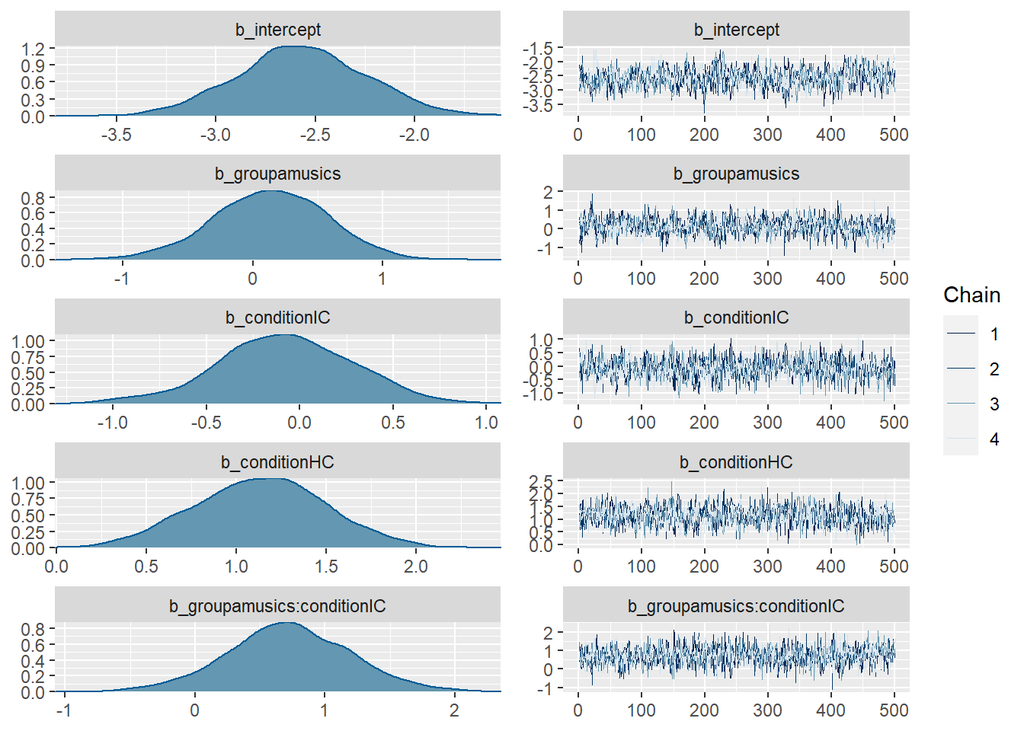

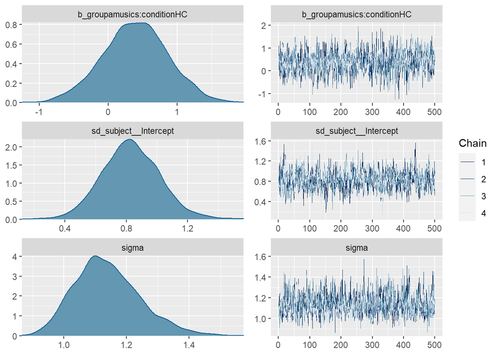

```r
plot(b1, ask = FALSE)
```

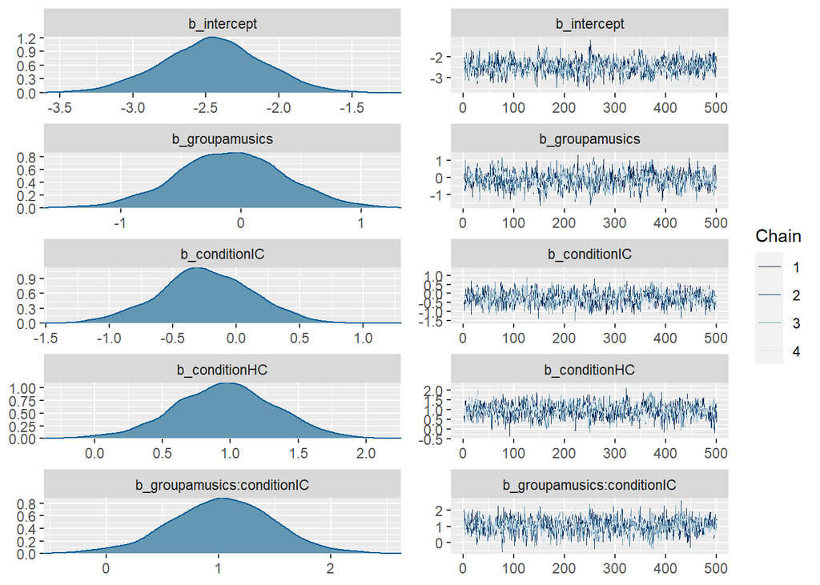

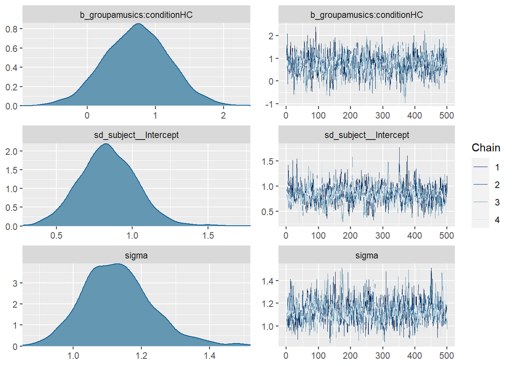

```r
plot(b2, ask = FALSE)
```

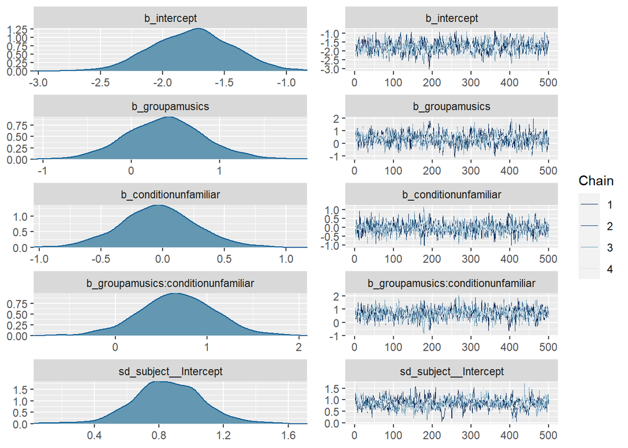

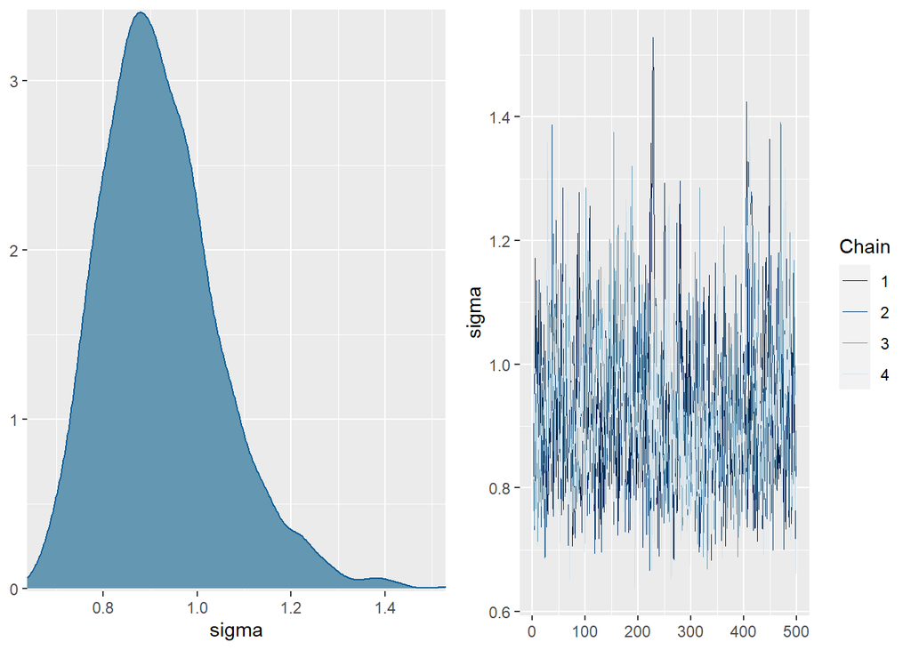

```r
plot(f1, ask = FALSE)
```

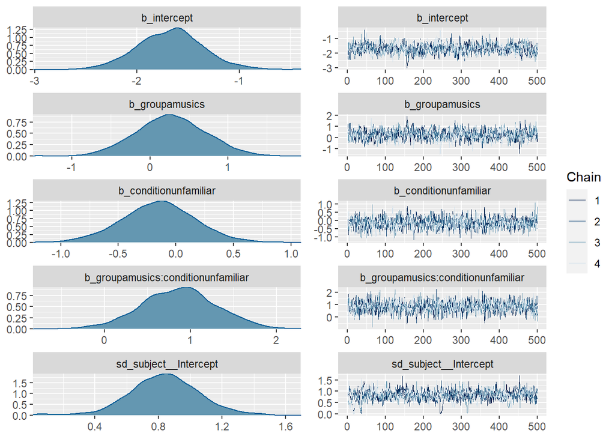

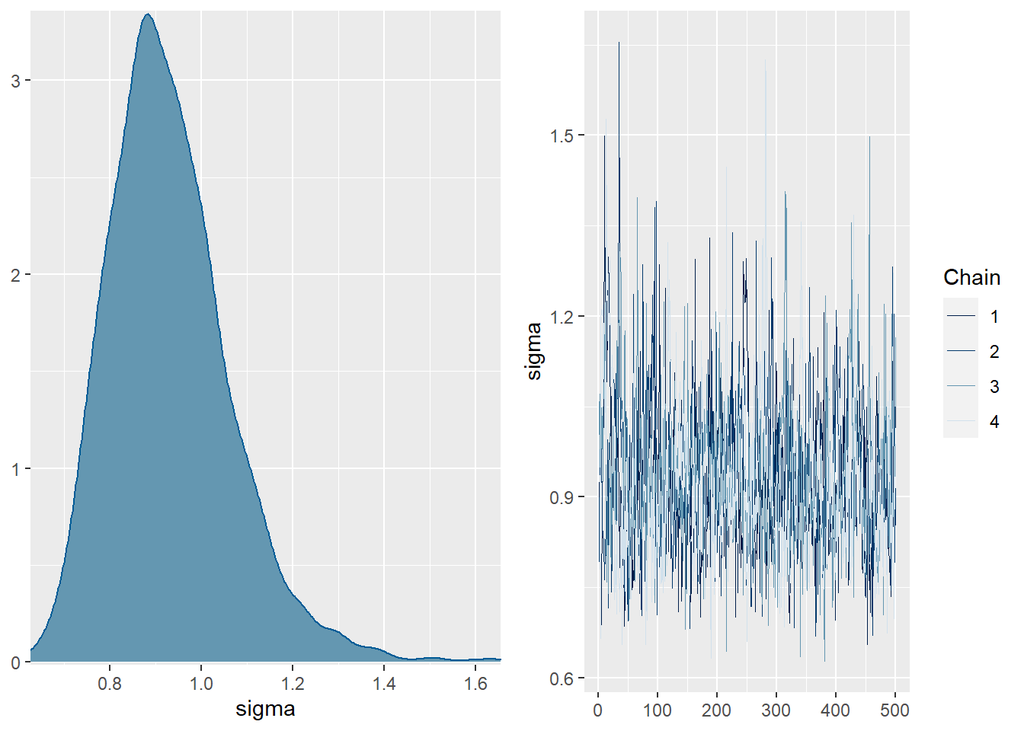

```r
plot(f2, ask = FALSE)
```